We’ll need a few packages to help us along the way:

```r
library(here) # file mgmt
library(semver) # the whole purpose of the blog post
library(rvest) # we'll need this to get version->year mappings
library(stringi) # b/c I'm still too lazy to switch to ore
library(hrbrthemes) # pretty graphs
library(tidyverse) # sane data processing idioms
```

By issuing a `stats` command to a `memcached` instance you can get a full list of statistics for the server. The recent newsmaking DDoS used this feature in conjunction with address spoofing to create 30 minutes of chaos for GitHub.

I sent a `stats` command (followed by a newline) to a vanilla `memcached` installation and it returned 53 lines (1108 bytes) of `STAT` results that look something like this:

```
STAT pid 7646
STAT uptime 141
STAT time 1520447469
STAT version 1.4.25 Ubuntu
STAT libevent 2.0.21-stable
...
```

The `version` bit is what we’re after, but there are plenty of other variables you could just as easily focus on if you use `memcached` in any production capacity.

I extracted raw version response data from our most recent scan for open `memcached` servers on the internet. For ethical reasons, I cannot blindly share the entire raw data set but hit up research@rapid7.com if you have a need or desire to work with this data.

Let’s read it in:

```r
version_strings <- read_lines(here("data", "versions.txt"))
```

And, now take a look at it:

```r
set.seed(2018-03-07)

sample(version_strings, 50)
```

```
##  [1] "STAT version 1.4.5"             "STAT version 1.4.17"
##  [3] "STAT version 1.4.25"            "STAT version 1.4.31"
##  [5] "STAT version 1.4.25"            "STAT version 1.2.6"
##  [7] "STAT version 1.2.6"             "STAT version 1.4.15"
##  [9] "STAT version 1.4.17"            "STAT version 1.4.4"
## [11] "STAT version 1.4.5"             "STAT version 1.2.6"
## [13] "STAT version 1.4.2"             "STAT version 1.4.14 (Ubuntu)"
## [15] "STAT version 1.4.7"             "STAT version 1.4.39"
## [17] "STAT version 1.4.4-14-g9c660c0" "STAT version 1.2.6"
## [19] "STAT version 1.2.6"             "STAT version 1.4.14"
## [21] "STAT version 1.4.4-14-g9c660c0" "STAT version 1.4.37"
## [23] "STAT version 1.4.13"            "STAT version 1.4.4"
## [25] "STAT version 1.4.17"            "STAT version 1.2.6"
## [27] "STAT version 1.4.37"            "STAT version 1.4.13"
## [29] "STAT version 1.4.25"            "STAT version 1.4.15"
## [31] "STAT version 1.4.25"            "STAT version 1.2.6"
## [33] "STAT version 1.4.10"            "STAT version 1.4.25"
## [35] "STAT version 1.4.25"            "STAT version 1.4.9"
## [37] "STAT version 1.4.30"            "STAT version 1.4.21"
## [39] "STAT version 1.4.15"            "STAT version 1.4.31"
## [41] "STAT version 1.4.13"            "STAT version 1.2.6"
## [43] "STAT version 1.4.13"            "STAT version 1.4.15"
## [45] "STAT version 1.4.19"            "STAT version 1.4.25 Ubuntu"
## [47] "STAT version 1.4.37"            "STAT version 1.4.4-14-g9c660c0"
## [49] "STAT version 1.2.6"             "STAT version 1.4.25 Ubuntu"
```

It’s in decent shape, but it needs some work if we’re going to do a version analysis with it. Let’s clean it up a bit:

```r
data_frame(
  string = stri_match_first_regex(version_strings, "STAT version (.*)$")[,2]
) -> versions

count(versions, string, sort = TRUE) %>%
  knitr::kable(format="markdown")
```

| string | n |
| --- | --- |
| 1.4.15 | 1966 |
| 1.2.6 | 1764 |
| 1.4.17 | 1101 |
| 1.4.37 | 949 |
| 1.4.13 | 725 |
| 1.4.4 | 531 |
| 1.4.25 | 511 |
| 1.4.20 | 368 |
| 1.4.14 (Ubuntu) | 334 |
| 1.4.21 | 309 |
| 1.4.25 Ubuntu | 290 |
| 1.4.24 | 259 |
| 1.4.2 | 211 |
| 1.4.4-14-g9c660c0 | 205 |
| 1.4.5 | 194 |
| 1.4.33 | 172 |
| 1.4.22 | 144 |
| 1.4.10 | 125 |
| 1.4.7 | 82 |
| 1.2.5 | 73 |
| 1.4.39 | 73 |
| 1.2.8 | 70 |
| 1.4.5_4_gaa7839e | 61 |
| 1.5.4 | 59 |
| 1.4.36 | 56 |
| 1.4.14 | 51 |
| 1.4.18 | 44 |
| 1.4.34 | 40 |
| 1.5.2 | 40 |
| 1.4.0 | 39 |
| 1.4.31 | 38 |
| 1.5.0 | 33 |
| 1.5.3 | 29 |
| 1.5.5 | 28 |
| 1.4.12 | 20 |
| 1.4.1 | 18 |
| UNKNOWN | 16 |
| 1.4.19 | 15 |
| 1.5.1 | 14 |
| 1.4.6 | 11 |
| 1.4.9 | 11 |
| 1.4.28 | 10 |
| 1.4.29 | 10 |
| 1.4.30 | 10 |
| 1.4.32 | 10 |
| 1.4.4-53-g0b7694c | 10 |
| 1.4.38 | 9 |
| 1.4.35 | 8 |
| 1.4.24 Ubuntu | 5 |
| 1.4.33 Ubuntu | 3 |
| 1.2.0 | 2 |
| 1.2.7 | 2 |
| 1.4.13_alt3 | 2 |
| 1.4.27 | 2 |
| 1.4.3 | 2 |
| 1.6.0_beta1_109_g298f23d | 2 |
| 1.3.0 | 1 |
| 1.4.26 | 1 |
| 1.4.35_80_g34ca206 | 1 |
| 1.4.4-54-g136cb6e | 1 |
| 1.4.5-xusd | 1 |
| 1.4.8 | 1 |
| 1.5.6 | 1 |
| UNKNOWN (Ubuntu) | 1 |

Much better! However, we really only need the major parts of the [semantic version string](https://semver.org/) for a macro view, so let’s remove non-version strings completely and extract just the *major*, *minor* and *patch* bits:

```r
filter(versions, !stri_detect_fixed(string, "UNKNOWN")) %>% # get rid of things we can't use
  mutate(string = stri_match_first_regex(
    string, "([[:digit:]]+\\.[[:digit:]]+\\.[[:digit:]]+)")[,2] # for a macro-view, the discrete sub-versions aren't important
  ) -> versions

count(versions, string, sort = TRUE) %>%
  knitr::kable(format="markdown")
```

| string | n |
| --- | --- |
| 1.4.15 | 1966 |
| 1.2.6 | 1764 |
| 1.4.17 | 1101 |
| 1.4.37 | 949 |
| 1.4.25 | 801 |
| 1.4.4 | 747 |
| 1.4.13 | 727 |
| 1.4.14 | 385 |
| 1.4.20 | 368 |
| 1.4.21 | 309 |
| 1.4.24 | 264 |
| 1.4.5 | 256 |
| 1.4.2 | 211 |
| 1.4.33 | 175 |
| 1.4.22 | 144 |
| 1.4.10 | 125 |
| 1.4.7 | 82 |
| 1.2.5 | 73 |
| 1.4.39 | 73 |
| 1.2.8 | 70 |
| 1.5.4 | 59 |
| 1.4.36 | 56 |
| 1.4.18 | 44 |
| 1.4.34 | 40 |
| 1.5.2 | 40 |
| 1.4.0 | 39 |
| 1.4.31 | 38 |
| 1.5.0 | 33 |
| 1.5.3 | 29 |
| 1.5.5 | 28 |
| 1.4.12 | 20 |
| 1.4.1 | 18 |
| 1.4.19 | 15 |
| 1.5.1 | 14 |
| 1.4.6 | 11 |
| 1.4.9 | 11 |
| 1.4.28 | 10 |
| 1.4.29 | 10 |
| 1.4.30 | 10 |
| 1.4.32 | 10 |
| 1.4.35 | 9 |
| 1.4.38 | 9 |
| 1.2.0 | 2 |
| 1.2.7 | 2 |
| 1.4.27 | 2 |
| 1.4.3 | 2 |
| 1.6.0 | 2 |
| 1.3.0 | 1 |
| 1.4.26 | 1 |
| 1.4.8 | 1 |
| 1.5.6 | 1 |

Much, much better! Now, let’s dig into the versions a bit. Using `semver` is dirt-simple. Just use `parse_version()` to get the usable bits out:

```r
ex_ver <- semver::parse_version(head(versions$string[1]))

ex_ver
```

```
## [1] Maj: 1 Min: 4 Pat: 25
```

```r
str(ex_ver)
```

```
## List of 1
##  $ :Class 'svptr' <externalptr>
##  - attr(*, "class")= chr "svlist"
```

It’s a special class, referncing an external pointer (the package relies on an underling C++ library and wraps everything up in a bow for us).

These objects can be compared, ordered, sorted, etc but I tend to just turn the parsed versions into a data frame that can be associated back with the main strings. That way we keep things pretty tidy and have tons of flexibility.

```r
bind_cols(
  versions,
  pull(versions, string) %>%
    semver::parse_version() %>%
    as.data.frame()
) %>%
  arrange(major, minor, patch) %>%
  mutate(string = factor(string, levels = unique(string))) -> versions

versions
```

```
## # A tibble: 11,157 x 6
##    string major minor patch prerelease build
##    <fct>  <int> <int> <int> <chr>      <chr>
##  1 1.2.0      1     2     0 ""         ""
##  2 1.2.0      1     2     0 ""         ""
##  3 1.2.5      1     2     5 ""         ""
##  4 1.2.5      1     2     5 ""         ""
##  5 1.2.5      1     2     5 ""         ""
##  6 1.2.5      1     2     5 ""         ""
##  7 1.2.5      1     2     5 ""         ""
##  8 1.2.5      1     2     5 ""         ""
##  9 1.2.5      1     2     5 ""         ""
## 10 1.2.5      1     2     5 ""         ""
## # ... with 11,147 more rows
```

Now we have a tidy data frame and I did the extra step of creating an ordered `factor` out of the version strings since they are ordinal values. With just this step, we have everything we need to do a basic plot shoing the version counts in-order:

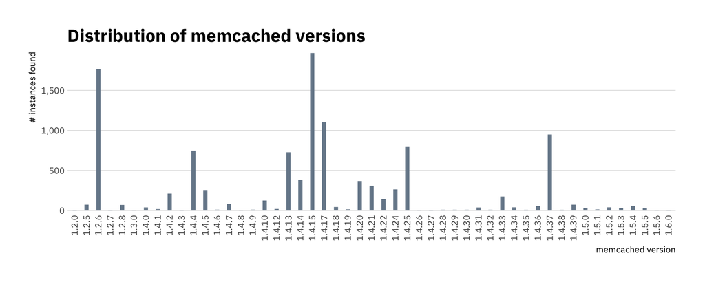

```r
count(versions, string) %>%
  ggplot() +
  geom_segment(
    aes(string, n, xend = string, yend = 0),
    size = 2, color = "lightslategray"
  ) +
  scale_y_comma() +
  labs(
    x = "memcached version", y = "# instances found",
    title = "Distribution of memcached versions"
  ) +
  theme_ipsum_ps(grid = "Y") +
  theme(axis.text.x = element_text(hjust = 1, vjust = 0.5, angle = 90))
```

That chart is informative on its own since we get the perspective that there are some really old versions exposed. But, how old are they? Projects like Chrome or Firefox churn through versions regularly/quickly (on purpose). To make more sense out of this we’ll need more info on releases.

This is where things can get ugly for folks who do not have commercial software management databases handy (or are analyzing a piece of software that hasn’t made it to one of those databases yet). The `memcached` project maintains a [wiki page](https://github.com/memcached/memcached/wiki/ReleaseNotes) of version history that’s mostly complete, and definitely complete enough for this exercise. It *will* some processing before we can associate a version to a year.

GitHub does not allow scraping of their site and — off the top of my head — I do not know if there is a “wiki” API endpoint, but I *do* know that you can tack on `.wiki.git` to the end of a GitHub repo to clone the wiki pages, so we’ll use that knowledge and the `git2r` package to gain access to the `ReleaseNotes.md` file that has the data we need:

```r
td <- tempfile("wiki", fileext="git") # temporary "directory"

dir.create(td)

git2r::clone(
  url = "git@github.com:memcached/memcached.wiki.git",
  local_path = td,
  credentials = git2r::cred_ssh_key() # need GH ssh keys setup!
) -> repo
```

[output not shown]

```r
read_lines(file.path(repo@path, "ReleaseNotes.md")) %>%
  keep(stri_detect_fixed, "[[ReleaseNotes") %>%
  stri_replace_first_regex(" \\* \\[\\[.*]] ", "") %>%
  stri_split_fixed(" ", 2, simplify = TRUE) %>%
  as_data_frame() %>%
  set_names(c("string", "release_year")) %>%
  mutate(string = stri_trim_both(string)) %>%
  mutate(release_year = stri_replace_first_fixed(release_year, "(", "")) %>% # remove leading parens
  mutate(release_year = stri_replace_all_regex(release_year, "\\-.*$", "")) %>% # we only want year so remove remaining date bits from easy ones
  mutate(release_year = stri_replace_all_regex(release_year, "^.*, ", "")) %>% # take care of most of the rest of the ugly ones
  mutate(release_year = stri_replace_all_regex(release_year, "^[[:alpha:]].* ", "")) %>% # take care of the straggler
  mutate(release_year = stri_replace_last_fixed(release_year, ")", "")) %>% # remove any trailing parens
  mutate(release_year = as.numeric(release_year)) -> memcached_releases # make it numeric

unlink(td, recursive = TRUE) # cleanup the git repo we downloaded

memcached_releases
```

```
## # A tibble: 49 x 2
##    string release_year
##    <chr>         <dbl>
##  1 1.5.6          2018
##  2 1.5.5          2018
##  3 1.5.4          2017
##  4 1.5.3          2017
##  5 1.5.2          2017
##  6 1.5.1          2017
##  7 1.5.0          2017
##  8 1.4.39         2017
##  9 1.4.38         2017
## 10 1.4.37         2017
## # ... with 39 more rows
```

We have more versions in our internet-scraped `memcached` `versions` data set than this wiki page has on it, so we need to restrict the official release history to what we have. Then, we only want a single instance of each year for the annotations, so we’ll have to do some further processing:

```r
filter(memcached_releases, string %in% unique(versions$string)) %>%
  mutate(string = factor(string, levels = levels(versions$string))) %>%
  group_by(release_year) %>%
  arrange(desc(string)) %>%
  slice(1) %>%
  ungroup() -> annotation_df

knitr::kable(annotation_df, "markdown")
```

| string | release_year |
| --- | --- |
| 1.4.4 | 2009 |
| 1.4.5 | 2010 |
| 1.4.10 | 2011 |
| 1.4.15 | 2012 |
| 1.4.17 | 2013 |
| 1.4.22 | 2014 |
| 1.4.25 | 2015 |
| 1.4.33 | 2016 |
| 1.5.4 | 2017 |
| 1.5.6 | 2018 |

Now, we’re ready to add the annotation layers! We’ll take a blind stab at it before adding in further aesthetic customizations:

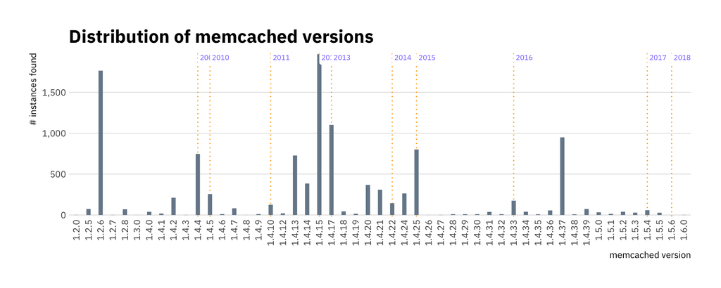

```r
version_counts <- count(versions, string) # no piping this time

ggplot() +
  geom_blank(data = version_counts,aes(string, n)) + # prime the scales
  geom_vline(
    data = annotation_df, aes(xintercept = as.numeric(string)),
    size = 0.5, linetype = "dotted", color = "orange"
  ) +
  geom_segment(
    data = version_counts,
    aes(string, n, xend = string, yend = 0),
    size = 2, color = "lightslategray"
  ) +
  geom_label(
    data = annotation_df, aes(string, Inf, label=release_year),
    family = font_ps, size = 2.5, color = "lightslateblue",
    hjust = 0, vjust = 1, label.size = 0
  ) +
  scale_y_comma() +
  labs(
    x = "memcached version", y = "# instances found",
    title = "Distribution of memcached versions"
  ) +
  theme_ipsum_ps(grid = "Y") +
  theme(axis.text.x = element_text(hjust = 1, vjust = 0.5, angle = 90))
```

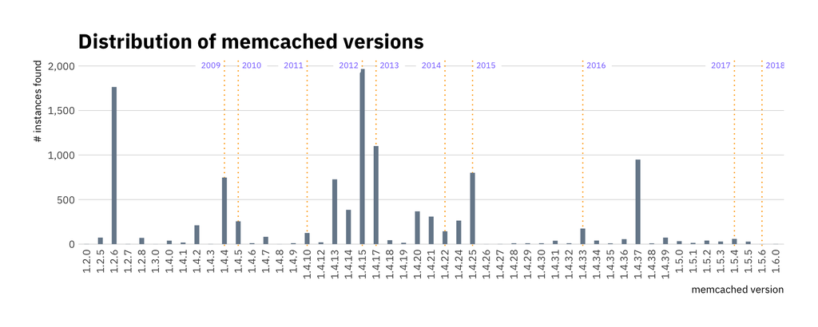

```r
ggplot() +
  geom_blank(data = version_counts,aes(string, n)) + # prime the scales
  geom_vline(
    data = annotation_df, aes(xintercept = as.numeric(string)),
    size = 0.5, linetype = "dotted", color = "orange"
  ) +
  geom_segment(
    data = version_counts,
    aes(string, n, xend = string, yend = 0),
    size = 2, color = "lightslategray"
  ) +
  geom_label(
    data = annotation_df, aes(string, Inf, label=release_year), vjust = 1,
    family = font_ps, size = 2.5, color = "lightslateblue", label.size = 0,
    hjust = c(1, 0, 1, 1, 0, 1, 0, 0, 1, 0),
    nudge_x = c(-0.1, 0.1, -0.1, -0.1, 0.1, -0.1, 0.1, 0.1, -0.1, 0.1)
  ) +
  scale_y_comma(limits = c(0, 2050)) +
  labs(
    x = "memcached version", y = "# instances found",
    title = "Distribution of memcached versions"
  ) +
  theme_ipsum_ps(grid = "Y") +
  theme(axis.text.x = element_text(hjust = 1, vjust = 0.5, angle = 90))
```

Now, we have version and year info to we can get a better idea of the scope of exposure (and, just how much technical debt many organizations have accrued).

With the ordinal version inforamtion we can also perform other statistical operations as well. All due to the `semver` package.

You can find this R project over at [GitHub](https://github.com/hrbrmstr/a-version)